# Final Project Report

R.A.Janith Santhush

2024-07-04

## Problem 1

Create a vector of five numbers of your choice between 0 and 10, save that vector to an object, and use the sum() function to calculate the sum of the numbers.

Put your code and solution here:

```r
vector <- c(3, 7, 2, 8, 1)

total_sum <- sum(vector)


total_sum
```

```
## [1] 21
```

## Problem 2

Create a data frame that includes two columns. One column must have the numbers 1 through 5, and the other column must have the numbers 6 through 10. The first column must be named “alpha” and the second column must be named “beta”. Name the object “my_dat”. Display the data.

Put your code and solution here:

```r
# Create a data frame with the specified columns
my_dat <- data.frame(alpha = 1:5, beta = 6:10)

# Display the data frame
print(my_dat)
```

```
##   alpha beta
## 1     1    6
## 2     2    7
## 3     3    8
## 4     4    9
## 5     5   10
```

## Problem 3

Using the data frame created in Problem 2, use the summary() command a create a five-number summary for the column named “beta”. Put your code and solution here:

```r
# Create the data frame as specified in Problem 2
my_dat <- data.frame(alpha = 1:5, beta = 6:10)

 #Use the summary() function to create a five-number summary for the column "beta"
summary(my_dat$beta)
```

```
##    Min. 1st Qu.  Median    Mean 3rd Qu.    Max.
##       6       7       8       8       9      10
```

## Problem 4

There is code for importing the example survey data that will run automatically in the setup chunk for this report (Line 13). Using that data, make a boxplot of the Family Income column using the Base R function (not a figure drawn using qplot). Include your name in the title for the plot. Your name should be in the title. Relabel that x-axis as “Family Income”.

Put your code and solution here:

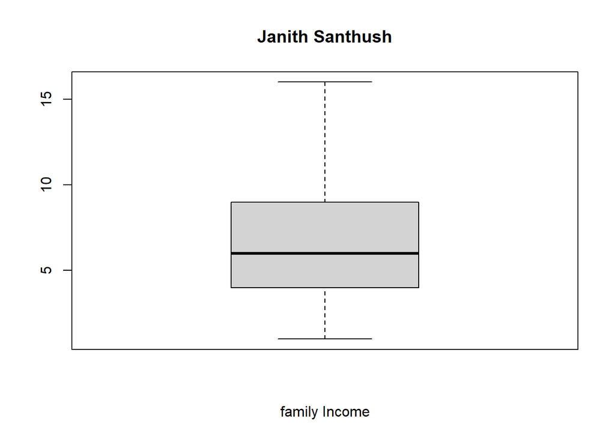

```r
boxplot(dat$faminc_new,
        main = "Janith Santhush",
        xlab = "family Income")
```

## Problem 5

Using the survey data, filter to subset the survey data so you only have male survey respondents who live in the northwest or midwest of the United States, are married, and identify as being interested in the news most of the time.

Put your code and solution here:

```r
filtered_data <- subset(dat,
                        gender=="1" &
                        region %in% c("1", "2") &
                        marstat == "1" &
                        newsint == "1")

# Display the filtered data
str(filtered_data)
```

```
## tibble [80 × 25] (S3: tbl_df/tbl/data.frame)
##  $ caseid      : num [1:80] 4.20e+08 4.13e+08 4.12e+08 4.14e+08 4.17e+08 ...
##  $ region      : num [1:80] 2 1 1 1 2 2 1 2 1 2 ...
##  $ gender      : num [1:80] 1 1 1 1 1 1 1 1 1 1 ...
##  $ educ        : num [1:80] 3 5 6 5 3 2 6 5 5 5 ...
##  $ edloan      : num [1:80] 2 1 2 1 1 2 2 2 2 2 ...
##  $ race        : num [1:80] 1 1 1 1 1 1 1 1 1 1 ...
##  $ hispanic    : num [1:80] 2 2 2 2 2 2 2 2 2 2 ...
##  $ employ      : num [1:80] 1 1 1 1 1 5 5 1 1 1 ...
##  $ marstat     : num [1:80] 1 1 1 1 1 1 1 1 1 1 ...
##  $ pid7        : num [1:80] 4 1 4 4 6 2 1 1 1 7 ...
##  $ ideo5       : num [1:80] 5 1 3 3 3 1 2 3 1 5 ...
##  $ pew_religimp: num [1:80] 4 4 4 1 2 4 4 2 4 1 ...
##  $ newsint     : num [1:80] 1 1 1 1 1 1 1 1 1 1 ...
##  $ faminc_new  : num [1:80] 10 11 10 9 10 2 13 8 7 11 ...
##  $ union       : num [1:80] 1 2 3 3 1 3 2 2 2 3 ...
##  $ investor    : num [1:80] 2 1 1 1 1 2 1 2 1 2 ...
##  $ CC18_308a   : num [1:80] 4 4 4 1 2 3 4 4 4 1 ...
##  $ CC18_310a   : num [1:80] 2 3 3 3 2 2 3 2 3 2 ...
##  $ CC18_310b   : num [1:80] 2 3 3 3 2 3 3 5 3 3 ...
##  $ CC18_310c   : num [1:80] 3 3 3 3 3 3 2 5 3 3 ...
##  $ CC18_310d   : num [1:80] 2 5 3 3 3 2 2 2 3 3 ...
##  $ CC18_325a   : num [1:80] 1 2 1 1 1 2 2 2 2 1 ...
##  $ CC18_325b   : num [1:80] 2 2 1 1 1 1 2 1 2 2 ...
##  $ CC18_325c   : num [1:80] 1 2 2 1 1 2 2 1 2 2 ...
##  $ CC18_325d   : num [1:80] 1 1 1 1 1 1 1 1 2 1 ...
```

## Problem 6

Filter the data the same as in Problem 5. Use a R function to create a frequency table for the responses for the question asking whether these survey respondents are invested in the stock market.

Put your code and solution here:

```r
filtered_data <- dat %>%
  filter(gender == 1, region %in% c(1, 2), marstat == 1, newsint == 1)

# Create a frequency table for the responses to the stock market investment question
stock_market_freq_table <- table(filtered_data$investor)

# Display the frequency table
print(stock_market_freq_table)
```

```
##
##  1  2
## 60 20
```

## Problem7

Going back to using all rows in the dataset, create a new column in the data using mutate that is equal to either 0, 1, or 2, to reflect whether the respondent supports increasing the standard deduction from 12,000 to 25,000, supports cutting the corporate income tax rate from 39 to 21 percent, or both (so, support for neither policy equals 0, one of the two policies equals 1, and both policies equals two). Name the column “tax_scale”. Hint: you’ll need to use recode() as well. Display the first twenty elements of the new column you create.

Put your code and solution here:

```r
library(dplyr)

# Create the new column using mutate and recode
df <- dat %>%
  mutate(tax_scale = recode(
    case_when(
      CC18_325d == 1 & CC18_325a == 2 ~ 1,  # Increase deduction only
      CC18_325d == 2 & CC18_325a == 1 ~ 1,  # Cut corporate tax only
      CC18_325d == 1 & CC18_325a == 1 ~ 2,  # Both policies
      TRUE ~ 0  # Neither policy supported
    ),
    `0` = 0,
    `1` = 1,
    `2` = 2
  ))

# Display the first twenty elements of the tax_scale column
head(df$tax_scale, 20)
```

```
##  [1] 2 1 1 1 1 2 2 2 1 1 0 1 0 2 0 1 0 1 1 1
```

```r
str(df)
```

```
## tibble [1,000 × 26] (S3: tbl_df/tbl/data.frame)
##  $ caseid      : num [1:1000] 4.18e+08 4.15e+08 4.14e+08 4.12e+08 4.17e+08 ...
##  $ region      : num [1:1000] 3 1 3 1 2 2 1 2 1 3 ...
##  $ gender      : num [1:1000] 1 2 2 2 1 1 1 2 1 1 ...
##  $ educ        : num [1:1000] 2 6 3 5 2 3 2 3 5 5 ...
##  $ edloan      : num [1:1000] 2 2 2 2 NA 2 2 2 1 NA ...
##  $ race        : num [1:1000] 1 1 2 6 4 1 1 1 1 1 ...
##  $ hispanic    : num [1:1000] 2 1 2 2 2 2 2 2 2 2 ...
##  $ employ      : num [1:1000] 5 1 1 5 8 1 5 7 1 1 ...
##  $ marstat     : num [1:1000] 3 1 4 3 5 1 5 1 1 5 ...
##  $ pid7        : num [1:1000] 6 2 2 3 1 4 5 7 1 1 ...
##  $ ideo5       : num [1:1000] 3 2 3 1 1 5 4 5 1 1 ...
##  $ pew_religimp: num [1:1000] 1 3 1 2 4 4 3 1 4 3 ...
##  $ newsint     : num [1:1000] 2 3 3 1 2 1 2 3 1 1 ...
##  $ faminc_new  : num [1:1000] 1 12 4 6 4 10 6 2 11 2 ...
##  $ union       : num [1:1000] 3 3 3 2 3 1 3 3 2 2 ...
##  $ investor    : num [1:1000] 2 2 1 1 2 2 1 2 1 2 ...
##  $ CC18_308a   : num [1:1000] 2 4 4 4 4 4 1 1 4 4 ...
##  $ CC18_310a   : num [1:1000] 2 3 2 3 2 2 3 2 3 2 ...
##  $ CC18_310b   : num [1:1000] 3 2 2 3 1 2 3 2 3 2 ...
##  $ CC18_310c   : num [1:1000] 3 5 2 3 1 3 2 3 3 2 ...
##  $ CC18_310d   : num [1:1000] 5 5 2 3 1 2 2 5 5 2 ...
##  $ CC18_325a   : num [1:1000] 1 2 1 2 2 1 1 1 2 2 ...
##  $ CC18_325b   : num [1:1000] 2 2 2 1 2 2 1 1 2 2 ...
##  $ CC18_325c   : num [1:1000] 1 2 1 2 2 1 1 1 2 2 ...
##  $ CC18_325d   : num [1:1000] 1 1 2 1 1 1 1 1 1 1 ...
##  $ tax_scale   : num [1:1000] 2 1 1 1 1 2 2 2 1 1 ...
```

## Problem 8

Use a frequency table command to show how many 0s, 1s, and 2s are in the column you created in Problem 7.

Put your code and solution here:

```r
# Create frequency table for tax_scale column
frequency_table <- table(df$tax_scale)

# Print the frequency table
print(frequency_table)
```

```
##
##   0   1   2
## 153 474 373
```

## Problem 09

Again using all rows in the original dataset, use summarise and group_by to calculate the average (mean) job of approval for President Trump in each of the four regions listed in the “region” column.

Put your code and solution here:

```r
dat$CC18_308a <- recode(dat$CC18_308a,
                        `1` = 1,  # Strongly approve
                        `2` = 2,  # Somewhat approve
                        `3` = 3,  # Somewhat disapprove
                        `4` = 4   # Strongly disapprove
)

# Calculate mean approval rating by region
average_approval <- dat %>%
  group_by(region) %>%
  summarise(mean_approval = mean(CC18_308a, na.rm = TRUE))

# Display the result
print(average_approval)
```

```
## # A tibble: 4 × 2
##   region mean_approval
##    <dbl>         <dbl>
## 1      1          2.79
## 2      2          2.84
## 3      3          2.69
## 4      4          3.03
```

## Problem 10

Again start with all rows in the original dataset, use summarise() to create a summary table for survey respondents who are not investors and who have an annual family income of between $40,000 and $119,999 per year. The table should have the mean, median and standard deviations for the importance of religion column.

Put your code and solution here:

```r
filtered_data <- dat %>%
  filter(investor == "2", faminc_new %in% c("4", "5", "6", "7", "8", "9", "10"))

# Create summary table with mean, median, and standard deviation for religion importance
summary_table <- filtered_data %>%
  summarise(
    mean_importance = mean(pew_religimp, na.rm = TRUE),
    median_importance = median(pew_religimp, na.rm = TRUE),
    sd_importance = sd(pew_religimp, na.rm = TRUE)
  )

# Print the summary table
print(summary_table)
```

```
## # A tibble: 1 × 3
##   mean_importance median_importance sd_importance
##             <dbl>             <dbl>         <dbl>
## 1            2.28                 2          1.17
```

## Problem 11

Use kable() and the the summarise() function to create a table with one row and three columns that provides the mean, median, and standard deviation for the column named faminc_new in the survey data.

Put your code and solution here:

```r
# Use summarise() to calculate mean, median, and standard deviation
summary_stats <- dat %>%
  summarise(
    Mean = mean(faminc_new, na.rm = TRUE),
    Median = median(faminc_new, na.rm = TRUE),
    SD = sd(faminc_new, na.rm = TRUE)
  )

# Print the table using kable()
kable(summary_stats, align = "r", caption = "Summary Statistics for faminc_new")
```

Summary Statistics for faminc_new

| Mean | Median | SD |
| --- | --- | --- |
| 6.518 | 6 | 3.292494 |

# Problem 12

With the survey data, use qplot() to make a histogram of the column named pid7. Change the x-axis label to “Seven Point Party ID” and the y-axis label to “Count”.

Put your code and solution here:

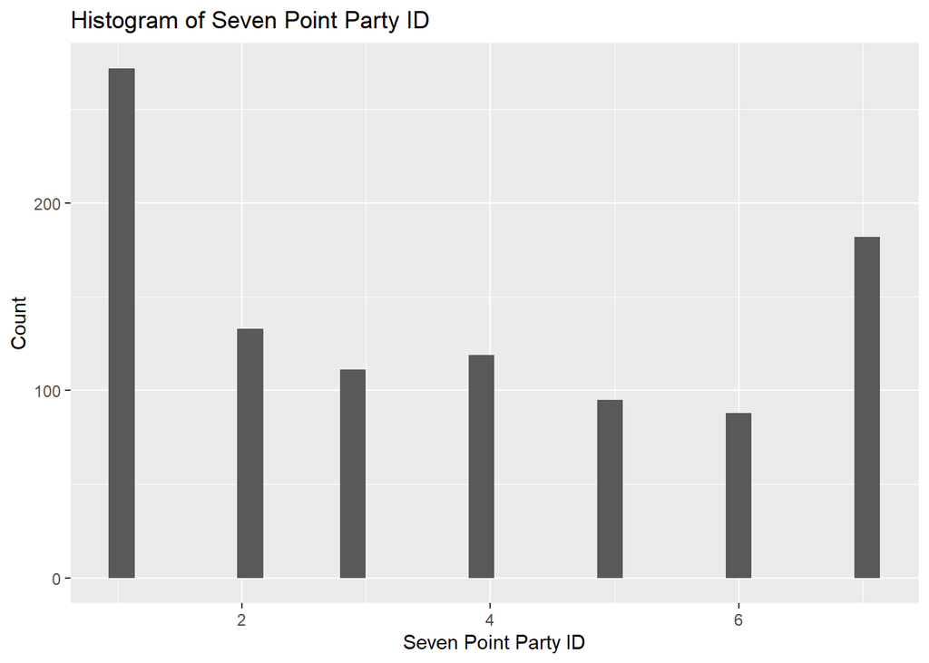

```r
library(ggplot2)

# Create histogram using qplot (quick plot)
qplot(data = dat, x = pid7, geom = "histogram",
      xlab = "Seven Point Party ID", ylab = "Count",
      main = "Histogram of Seven Point Party ID")
```